# Drumming regional variation: pdfas, repdfas, glmms statistics

Vesta Eleuteri

2024-12-10

# Introduction

This document accompanies the manuscript “Chimpanzee drumming shows rhythmicity and subspecies variation” Vesta Eleuteri et al. (2024).

Here we tested for regional variation in chimpanzee drumming by comparing drumming structure across communities, across populations, and between subspecies. We first used permuted discriminant function analyses (pDFA) to test for the group differences and then used repeated discriminant function analyses (repDFA) and generalized linear mixed models (glmms) to identify the key variables discriminating the groups in significant pDFAs.

Here we also tested for regional variation in chimpanzee drumming behaviour by comparing the timing of drumming onset during pant-hoot vocalizations across communities, across populations, and between subspecies. We used glmms to test for the group differences.

# Preliminaries

## Load packages, functions, data

```r
# for easy loading of packages
if (!require("pacman")) install.packages("pacman")
# load packages
p_load("here", "devtools", "gobbios/cfp", "gobbios/cfp@v.0.1.0", "cfp", "MASS", "lmerTest", "lme4", "MuMIn", "dplyr", "knitr", "kableExtra")
here <- here::here

# for relative file paths (e.g. here('Input', 'file.csv'))
here::i_am(file.path("pdfa_repdfa_glmm.Rmd"))
```

```
## here() starts at /Users/ve/Desktop/Drumming/Acoustic data analyses 2023/Analyses
```

```r
# get custom R functions
source(here("functions", "pdfa_functions.r"))
source(here("functions", "repDFA_nested.r"))
source(here("functions", "diagnostic_fcns.r"))
source(here("functions", "glmm_stability.r"))
source(here("functions", "boot_glmm.r"))

# Knitr output settings
knitr::opts_chunk$set(
  warning = FALSE,
  message = FALSE,
  out.width = "100%",
  fig.width = 10,
  fig.height = 10,
  cache = TRUE
)

# load data
xdata <- read.csv(here("dataframes", "drumming_wide.csv"))
```

# Summary data

## Summary data community

```r
summary_stats_com <- xdata %>%
  group_by(Subspecies, Population, Community) %>%
  dplyr::summarise(
    Number_Drums = n(),
    Mean_N_hits = round(mean(N_hits, na.rm = TRUE), 3),
    SD_N_hits = round(sd(N_hits, na.rm = TRUE), 3),
    Mean_Bout_Duration = round(mean(Total_bout_duration, na.rm = TRUE), 3),
    SD_Bout_Duration = round(sd(Total_bout_duration, na.rm = TRUE), 3),
    Mean_Bout_cv = round(mean(Bout_cv, na.rm = TRUE), 3),
    SD_Bout_cv = round(sd(Bout_cv, na.rm = TRUE), 3),
    Mean_Bout_npvi = round(mean(Bout_npvi, na.rm = TRUE), 3),
    SD_Bout_npvi = round(sd(Bout_npvi, na.rm = TRUE), 3),
    Mean_Entropy = round(mean(Bout_entropy, na.rm = TRUE), 3),
    SD_Entropy = round(sd(Bout_entropy, na.rm = TRUE), 3),
    .groups = "drop"
  )
summary_stats_com
```

```
## # A tibble: 11 × 14
##    Subspecies Population Community   Number_Drums Mean_N_hits SD_N_hits
##    <chr>      <chr>      <chr>              <int>       <dbl>     <dbl>
##  1 Eastern    Budongo    Sonso                 73        5.74      3.12
##  2 Eastern    Budongo    Waibira               64        4.69      2.38
##  3 Eastern    Gombe      Kasekela               8        7.12      2.85
##  4 Eastern    Kibale     Kanyawara             17        5.53      2.50
##  5 Western    Fongoli    Fongoli               12        8.08      4.23
##  6 Western    Nimba      Gahtoy                10       10.7       4.11
##  7 Western    Nimba      Tongbongbon           24        7.96      3.78
##  8 Western    Taï        East                  65        8.48      4.21
##  9 Western    Taï        Middle                22        6.64      3.00
## 10 Western    Taï        North                 54        7.13      4.11
## 11 Western    Taï        South                 22        9.5       6.23
## # ℹ 8 more variables: Mean_Bout_Duration <dbl>, SD_Bout_Duration <dbl>,
## #   Mean_Bout_cv <dbl>, SD_Bout_cv <dbl>, Mean_Bout_npvi <dbl>,
## #   SD_Bout_npvi <dbl>, Mean_Entropy <dbl>, SD_Entropy <dbl>
```

## Summary data population

```r
summary_stats_pop <- xdata %>%
  group_by(Subspecies, Population) %>%
  dplyr::summarise(
    Number_Drums = n(),
    Mean_N_hits = round(mean(N_hits, na.rm = TRUE), 3),
    SD_N_hits = round(sd(N_hits, na.rm = TRUE), 3),
    Mean_Bout_Duration = round(mean(Total_bout_duration, na.rm = TRUE), 3),
    SD_Bout_Duration = round(sd(Total_bout_duration, na.rm = TRUE), 3),
    Mean_Bout_cv = round(mean(Bout_cv, na.rm = TRUE), 3),
    SD_Bout_cv = round(sd(Bout_cv, na.rm = TRUE), 3),
    Mean_Bout_npvi = round(mean(Bout_npvi, na.rm = TRUE), 3),
    SD_Bout_npvi = round(sd(Bout_npvi, na.rm = TRUE), 3),
    Mean_Entropy = round(mean(Bout_entropy, na.rm = TRUE), 3),
    SD_Entropy = round(sd(Bout_entropy, na.rm = TRUE), 3),
    .groups = "drop"
  )
summary_stats_pop
```

```
## # A tibble: 6 × 13
##   Subspecies Population Number_Drums Mean_N_hits SD_N_hits Mean_Bout_Duration
##   <chr>      <chr>             <int>       <dbl>     <dbl>              <dbl>
## 1 Eastern    Budongo             137        5.25      2.84               1.10
## 2 Eastern    Gombe                 8        7.12      2.85               1.63
## 3 Eastern    Kibale               17        5.53      2.50               1.10
## 4 Western    Fongoli              12        8.08      4.23               1.88
## 5 Western    Nimba                34        8.76      4.02               1.44
## 6 Western    Taï                 163        7.92      4.43               1.52
## # ℹ 7 more variables: SD_Bout_Duration <dbl>, Mean_Bout_cv <dbl>,
## #   SD_Bout_cv <dbl>, Mean_Bout_npvi <dbl>, SD_Bout_npvi <dbl>,
## #   Mean_Entropy <dbl>, SD_Entropy <dbl>
```

## Summary data subspecies

```r
summary_stats_sub <- xdata %>%
  group_by(Subspecies) %>%
  dplyr::summarise(
    Number_Drums = n(),
    Mean_N_hits = round(mean(N_hits, na.rm = TRUE), 3),
    SD_N_hits = round(sd(N_hits, na.rm = TRUE), 3),
    Mean_Bout_Duration = round(mean(Total_bout_duration, na.rm = TRUE), 3),
    SD_Bout_Duration = round(sd(Total_bout_duration, na.rm = TRUE), 3),
    Mean_Bout_cv = round(mean(Bout_cv, na.rm = TRUE), 3),
    SD_Bout_cv = round(sd(Bout_cv, na.rm = TRUE), 3),
    Mean_Bout_npvi = round(mean(Bout_npvi, na.rm = TRUE), 3),
    SD_Bout_npvi = round(sd(Bout_npvi, na.rm = TRUE), 3),
    Mean_Entropy = round(mean(Bout_entropy, na.rm = TRUE), 3),
    SD_Entropy = round(sd(Bout_entropy, na.rm = TRUE), 3),
    .groups = "drop"
  )
summary_stats_sub
```

```
## # A tibble: 2 × 12
##   Subspecies Number_Drums Mean_N_hits SD_N_hits Mean_Bout_Duration
##   <chr>             <int>       <dbl>     <dbl>              <dbl>
## 1 Eastern             162        5.37      2.82               1.12
## 2 Western             209        8.07      4.35               1.52
## # ℹ 7 more variables: SD_Bout_Duration <dbl>, Mean_Bout_cv <dbl>,
## #   SD_Bout_cv <dbl>, Mean_Bout_npvi <dbl>, SD_Bout_npvi <dbl>,
## #   Mean_Entropy <dbl>, SD_Entropy <dbl>
```

## Summary data all

```r
summary_stats_all <- xdata %>%
  dplyr::summarise(
    Number_Drums = n(),
    Mean_N_hits = round(mean(N_hits, na.rm = TRUE), 3),
    SD_N_hits = round(sd(N_hits, na.rm = TRUE), 3),
    Mean_Bout_Duration = round(mean(Total_bout_duration, na.rm = TRUE), 3),
    SD_Bout_Duration = round(sd(Total_bout_duration, na.rm = TRUE), 3),
    Mean_Bout_cv = round(mean(Bout_cv, na.rm = TRUE), 3),
    SD_Bout_cv = round(sd(Bout_cv, na.rm = TRUE), 3),
    Mean_Bout_npvi = round(mean(Bout_npvi, na.rm = TRUE), 3),
    SD_Bout_npvi = round(sd(Bout_npvi, na.rm = TRUE), 3),
    Mean_Entropy = round(mean(Bout_entropy, na.rm = TRUE), 3),
    SD_Entropy = round(sd(Bout_entropy, na.rm = TRUE), 3),
    .groups = "drop"
  )
summary_stats_all
```

```
##   Number_Drums Mean_N_hits SD_N_hits Mean_Bout_Duration SD_Bout_Duration
## 1          371       6.889     3.984              1.349            0.963
##   Mean_Bout_cv SD_Bout_cv Mean_Bout_npvi SD_Bout_npvi Mean_Entropy SD_Entropy
## 1        0.555      0.327         66.531       37.599        0.972      1.199
```

# Analyses for regional variation in drumming structure

## Sort data

```r
## Sort data
range(xdata$Total_bout_duration)
```

```
## [1] 0.08854 5.46734
```

```r
range(xdata$N_hits)
```

```
## [1]  3 27
```

```r
range(xdata$Bout_cv)
```

```
## [1] 0.000000 1.726164
```

```r
range(xdata$Bout_npvi)
```

```
## [1]   0.0000 173.5817
```

```r
range(xdata$Bout_entropy)
```

```
## [1] 0.000000 8.428395
```

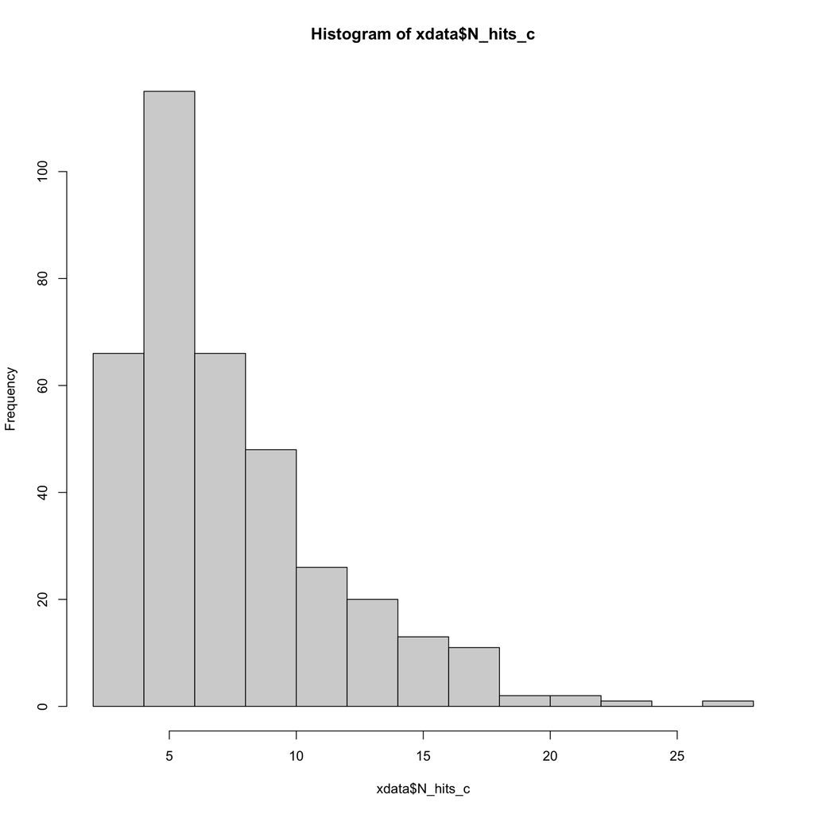

```r
## Add constants to variables to logtransform all non-normal variables with 0 bounds
c <- 0.0001
xdata$Total_bout_duration_c <- xdata$Total_bout_duration + c
xdata$N_hits_c <- xdata$N_hits + c
xdata$Bout_cv_c <- xdata$Bout_cv + c
xdata$Bout_npvi_c <- xdata$Bout_npvi + c
xdata$Bout_entropy_c <- xdata$Bout_entropy + c

# Logtransform skewed distributions
hist(xdata$N_hits_c) # skewed
```

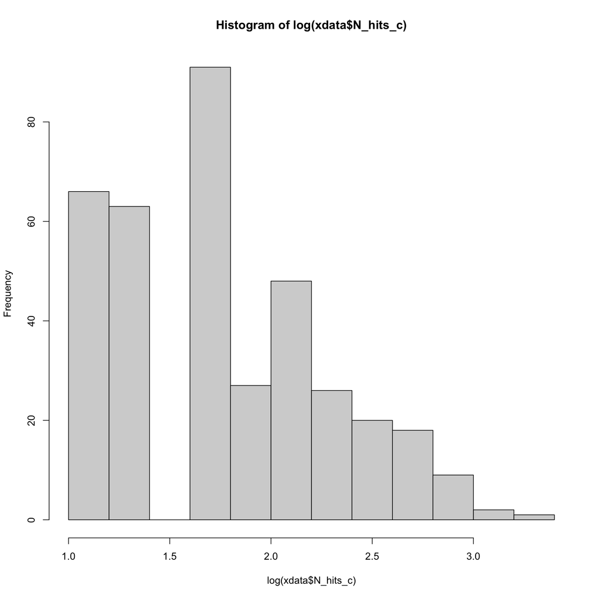

```r
hist(log(xdata$N_hits_c)) # better
```

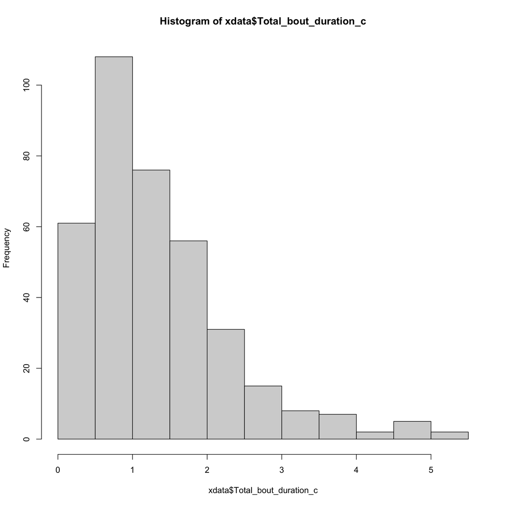

```r
xdata$log.N_hits_c <- log(xdata$N_hits_c) # logtransform

hist(xdata$Total_bout_duration_c) # skewed
```

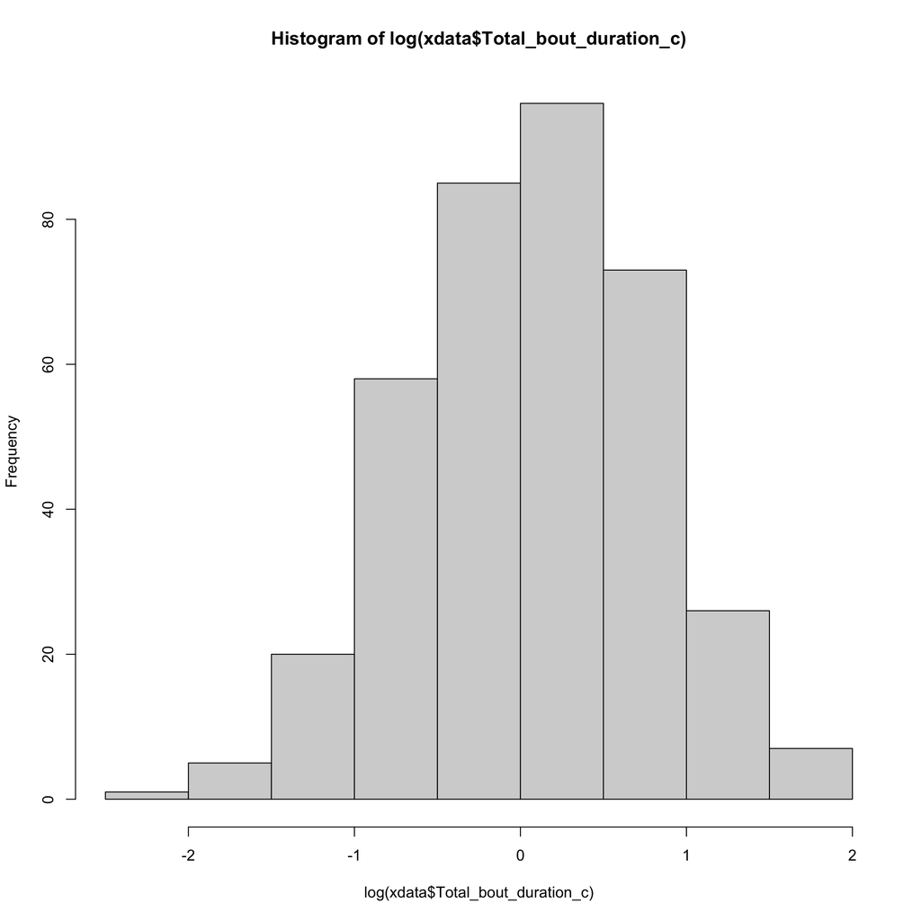

```r
hist(log(xdata$Total_bout_duration_c)) # better
```

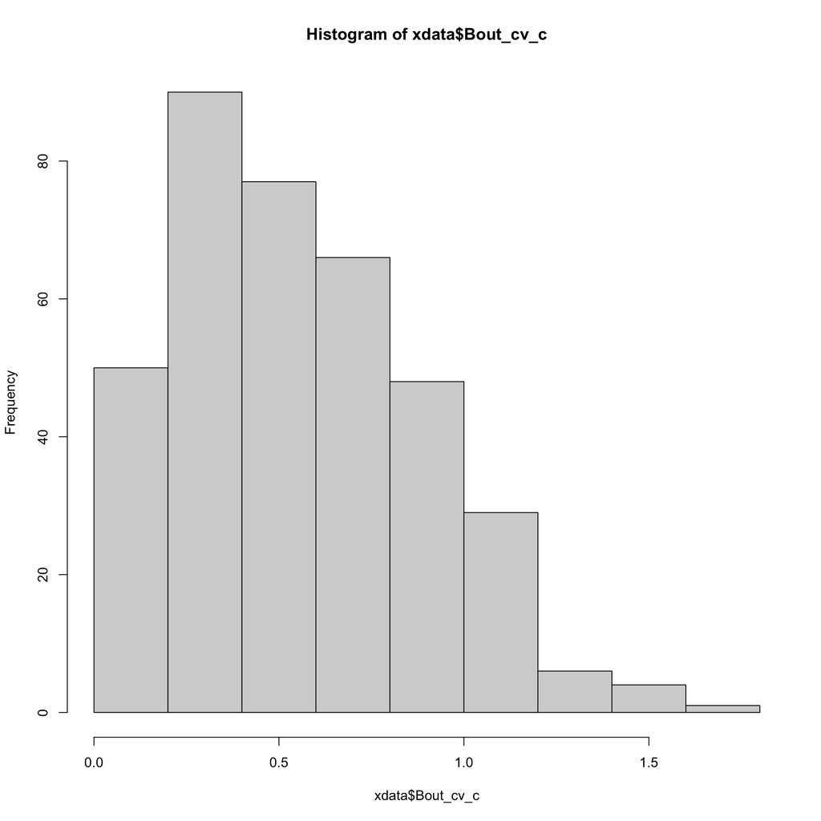

```r
xdata$log.Total_bout_duration_c <- log(xdata$Total_bout_duration_c) # logtransform

hist(xdata$Bout_cv_c) # slightly skewed
```

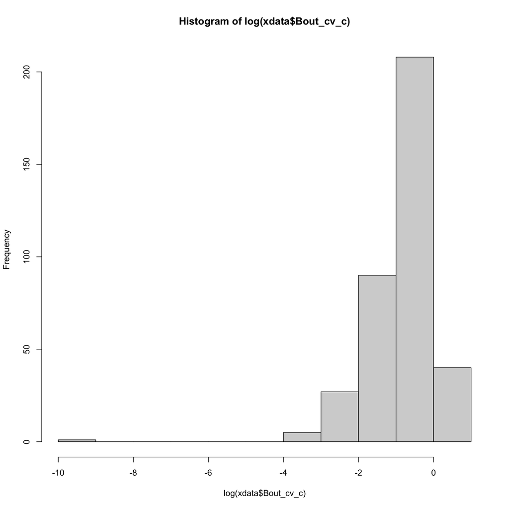

```r
hist(log(xdata$Bout_cv_c)) # skewed on other side so do not logtransform
```

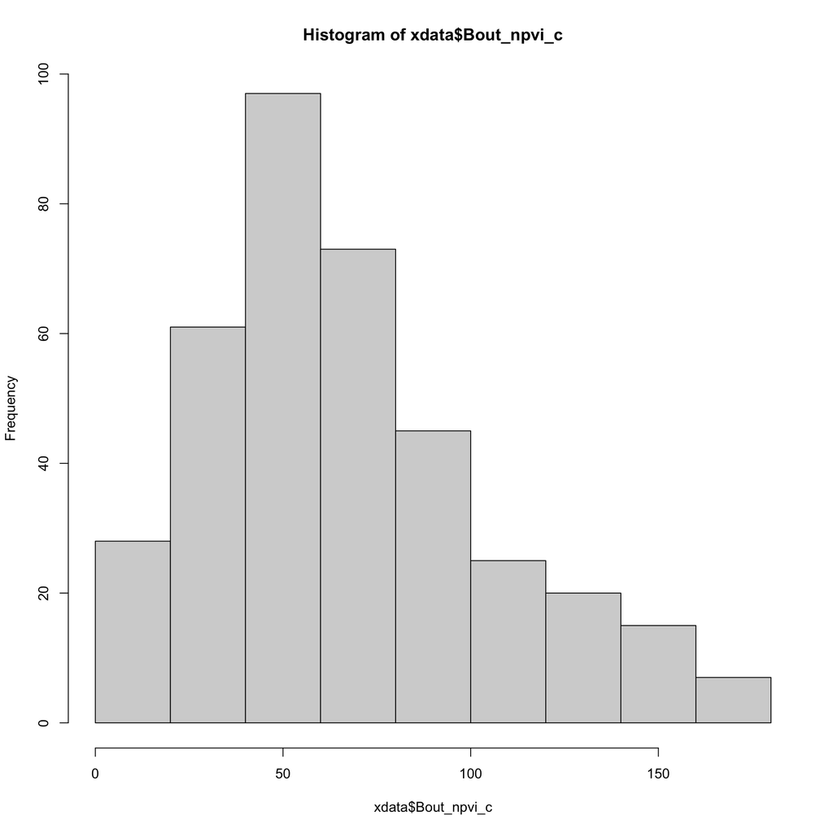

```r
hist(xdata$Bout_npvi_c) # slightly skewed
```

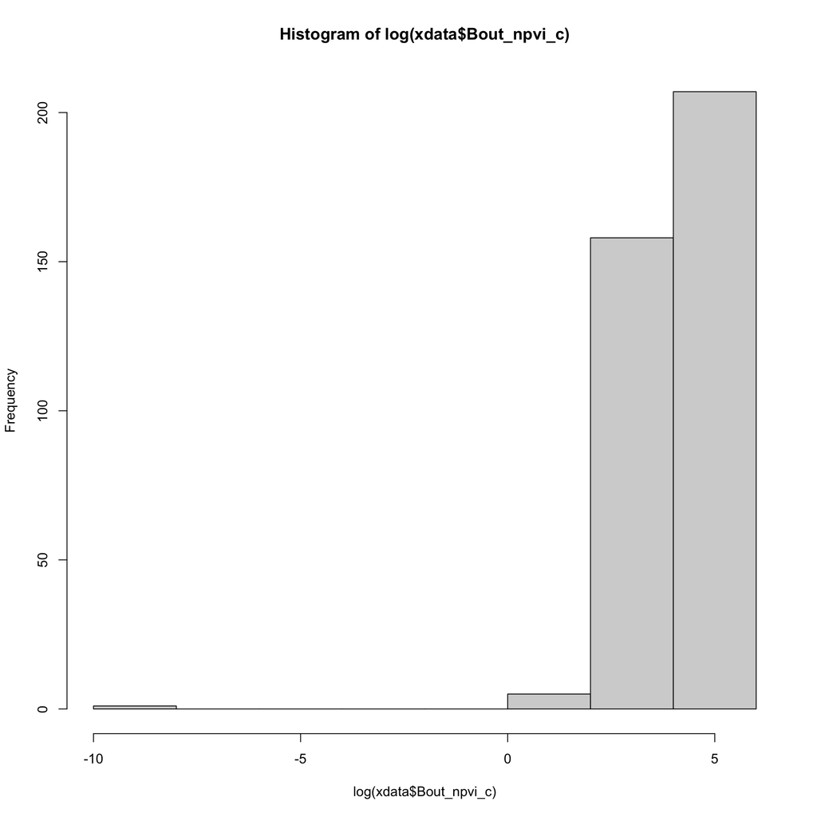

```r
hist(log(xdata$Bout_npvi_c)) # skewed on other side so do not logtransform
```

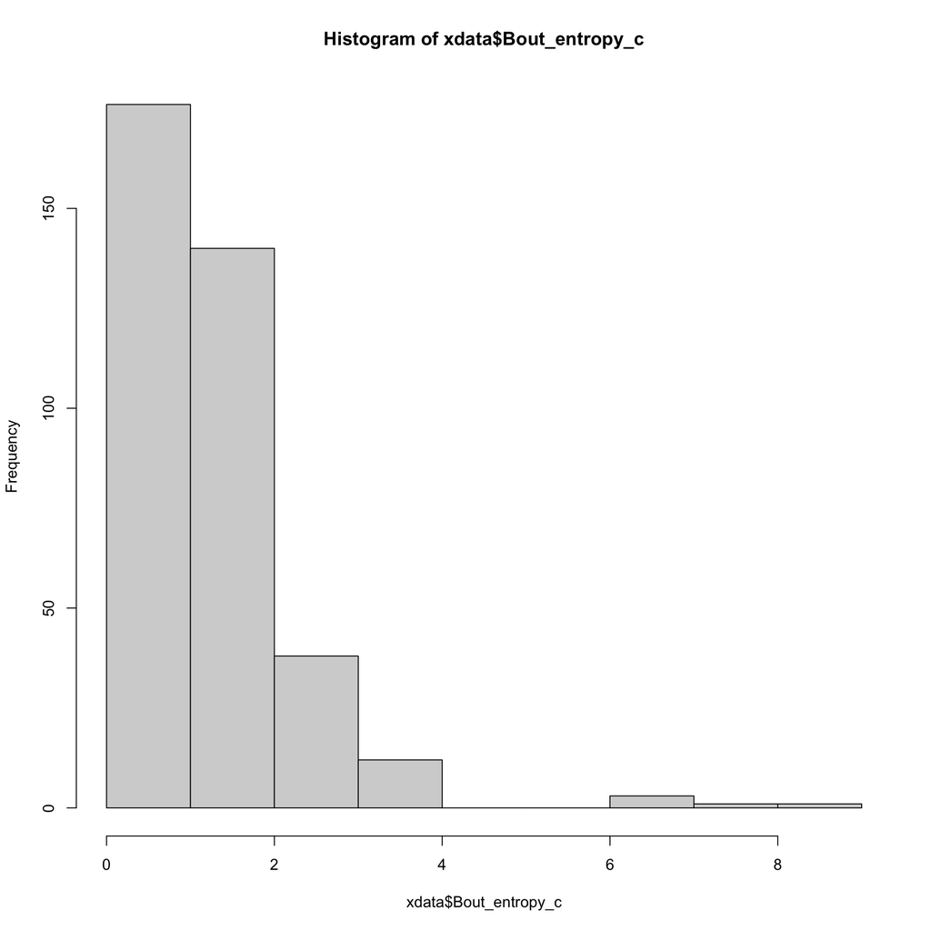

```r
hist(xdata$Bout_entropy_c) # slightly skewed
```

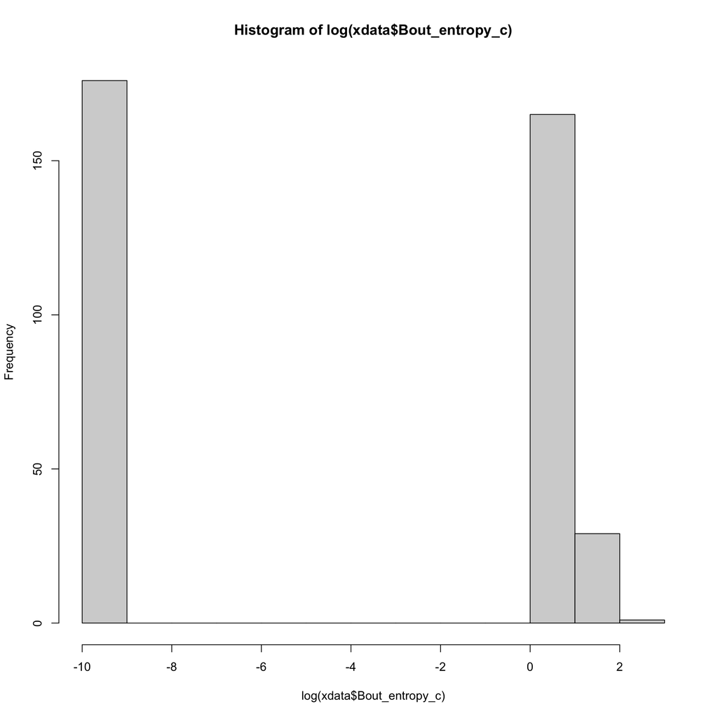

```r
hist(log(xdata$Bout_entropy_c)) # skewed on other side so do not logtransform
```

## Community pDFA

We first tested for regional variation using a pDFA to compare drumming structure across communities.

```r
set.seed(131)
pdfa.res.communities <- pDFA.nested(
  test.fac = "Pop_com_code", contr.fac = "Com_indiv_code",
  variables = c(
    "log.Total_bout_duration_c", "log.N_hits_c",
    "Bout_cv_c", "Bout_npvi_c", "Bout_entropy_c"
  ),
  restrict.by = NULL,
  n.contr.fac.levels.to.sel = NULL,
  n.to.sel.per.contr.fac.level = NULL, n.sel = 100, n.perm = 1000,
  pdfa.data = xdata
)

pdfa.res.communities$result
```

```
##                    no.corr.classified.selected
##                                       25.36000
##           expected.no.corr.classified.selected
##                                       22.52136
##          percent.correctly.classified.selected
##                                       38.42424
## expected.percent.correctly.classified.selected
##                                       34.12327
##                                 P.for.selected
##                                        0.21900
##                       no.corr.cross.classified
##                                       64.54000
##              expected.no.corr.cross.classified
##                                       38.94954
##                  percent.corr.cross.classified
##                                       21.16066
##         expected.percent.corr.cross.classified
##                                       12.77034
##                         P.for.cross.classified
##                                        0.01400
##                         no.levels.contr.factor
##                                       47.00000
##                no.levels.contr.factor.selected
##                                       22.00000
##                          no.levels.test.factor
##                                       11.00000
##                                       no.cases
##                                      371.00000
##                              no.cases.selected
##                                       66.00000
##     no.cases.selected.per.level.of.control.fac
##                                        3.00000
##                                no.permutations
##                                     1000.00000
##                           no.random.selections
##                                      100.00000
```

The pDFA is significant showing that drumming structure varies across communities. We thus used a repDFA to identify the key variables significantly discriminating the communities.

### Communtiy repDFA

```r
set.seed(5)
ImpVars_all_comms_allvabs <- repDFA_nested(xdata,
  testfactor = "Pop_com_code",
  balancefactor = c("Pop_com_code", "Com_indiv_code"),
  varnames = c(
    "log.Total_bout_duration_c", "log.N_hits_c",
    "Bout_cv_c", "Bout_npvi_c", "Bout_entropy_c"
  ),
  npercomb = 3, nrand = 1000
)

All_comms_allvabs_repDFA_res_df1 <- table(ImpVars_all_comms_allvabs$df1_best)
All_comms_allvabs_repDFA_res_df1
```

```
##
##            Bout_entropy_c               Bout_npvi_c              log.N_hits_c
##                         8                       524                       460
## log.Total_bout_duration_c
##                         8
```

```r
All_comms_allvabs_repDFA_res_df2 <- table(ImpVars_all_comms_allvabs$df2_best)
All_comms_allvabs_repDFA_res_df2
```

```
##
##                 Bout_cv_c            Bout_entropy_c               Bout_npvi_c
##                        17                       226                       181
##              log.N_hits_c log.Total_bout_duration_c
##                        33                       543
```

The repDFA identified as key variables on discriminant 1: nPVI and Number of hits, on discriminant 2: total bout duration and entropy. We thus used glmms to test if these variables significantly vary across the communities.

### Community glmm nPVI

```r
## Run model
Model_npvi <- lmer(Bout_npvi_c ~ Community +
  (1 | Individual), data = xdata, REML = F)

## Full-null model comparison
null_Model_npvi <- lmer(Bout_npvi_c ~ (1 | Individual), data = xdata, REML = F)
Chisq_Model_npvi <- as.data.frame(anova(null_Model_npvi, Model_npvi, test = "Chisq")) # sig
Chisq_Model_npvi <- round(Chisq_Model_npvi, 3)
Chisq_Model_npvi
```

```
##                 npar      AIC      BIC    logLik deviance  Chisq Df Pr(>Chisq)
## null_Model_npvi    3 3686.482 3698.230 -1840.241 3680.482     NA NA         NA
## Model_npvi        13 3675.862 3726.773 -1824.931 3649.862 30.619 10      0.001
```

nPVI significantly varies across communities.

### Community glmm N hits

```r
## Run model
Model_numhits <- lmer(log.N_hits_c ~ Community +
  (1 | Individual), data = xdata, REML = F)

## Full-null model comparison
null_Model_numhits <- lmer(log.N_hits_c ~ (1 | Individual), data = xdata, REML = F)
Chisq_Model_numhits <- as.data.frame(anova(null_Model_numhits, Model_numhits, test = "Chisq"))
Chisq_Model_numhits <- round(Chisq_Model_numhits, 3)
Chisq_Model_numhits
```

```
##                    npar     AIC     BIC   logLik deviance  Chisq Df Pr(>Chisq)
## null_Model_numhits    3 511.915 523.664 -252.958  505.915     NA NA         NA
## Model_numhits        13 501.004 551.914 -237.502  475.004 30.912 10      0.001
```

N hits significantly varies across communities.

### Community glmm bout duration

```r
## Run model
Model_drumduration <- lmer(log.Total_bout_duration_c ~ Community +
  (1 | Individual), data = xdata, REML = F)

## Full-null model comparison
null_Model_drumduration <- lmer(log.Total_bout_duration_c ~ (1 | Individual), data = xdata, REML = F)
Chisq_Model_drumduration <- as.data.frame(anova(null_Model_drumduration, Model_drumduration, test = "Chisq"))
Chisq_Model_drumduration
```

```
##                         npar      AIC      BIC    logLik deviance    Chisq Df
## null_Model_drumduration    3 787.5523 799.3009 -390.7762 781.5523       NA NA
## Model_drumduration        13 789.8177 840.7284 -381.9089 763.8177 17.73457 10
##                         Pr(>Chisq)
## null_Model_drumduration         NA
## Model_drumduration       0.0596095
```

Bout duration does not significantly vary across communities.

### Community glmm entropy

```r
## Run model
Model_entropy <- lmer(Bout_entropy_c ~ Community +
  (1 | Individual), data = xdata, REML = F)

## Full-null model comparison
null_Model_entropy <- lmer(Bout_entropy_c ~ (1 | Individual), data = xdata, REML = F)
Chisq_Model_entropy <- as.data.frame(anova(null_Model_entropy, Model_entropy, test = "Chisq"))
Chisq_Model_entropy <- round(Chisq_Model_entropy, 3)
Chisq_Model_entropy
```

```
##                    npar      AIC      BIC   logLik deviance  Chisq Df
## null_Model_entropy    3 1150.653 1162.401 -572.326 1144.653     NA NA
## Model_entropy        13 1158.379 1209.289 -566.189 1132.379 12.274 10
##                    Pr(>Chisq)
## null_Model_entropy         NA
## Model_entropy           0.267
```

Entropy does not significantly vary across communities.

## Confirmatory Subspecies pDFA

Because plots (see main_plots.Rmd) suggest that the variation lies across communities of different subspecies, we followed up the community comparison with a pDFA comparing the two subspecies (eastern and western).

```r
set.seed(126)
pdfa.res.subspecies <- pDFA.nested(
  test.fac = "Subspecies", contr.fac = "Com_indiv_code",
  variables = c(
    "log.Total_bout_duration_c", "log.N_hits_c",
    "Bout_cv_c", "Bout_npvi_c", "Bout_entropy_c"
  ), restrict.by = NULL,
  n.contr.fac.levels.to.sel = NULL,
  n.to.sel.per.contr.fac.level = NULL, n.sel = 100, n.perm = 1000,
  pdfa.data = xdata
)

pdfa.res.subspecies$result
```

```
##                    no.corr.classified.selected
##                                       91.42000
##           expected.no.corr.classified.selected
##                                       74.60242
##          percent.correctly.classified.selected
##                                       72.55556
## expected.percent.correctly.classified.selected
##                                       59.20827
##                                 P.for.selected
##                                        0.00300
##                       no.corr.cross.classified
##                                      177.61000
##              expected.no.corr.cross.classified
##                                      133.51761
##                  percent.corr.cross.classified
##                                       72.49388
##         expected.percent.corr.cross.classified
##                                       54.49698
##                         P.for.cross.classified
##                                        0.00200
##                         no.levels.contr.factor
##                                       47.00000
##                no.levels.contr.factor.selected
##                                       42.00000
##                          no.levels.test.factor
##                                        2.00000
##                                       no.cases
##                                      371.00000
##                              no.cases.selected
##                                      126.00000
##     no.cases.selected.per.level.of.control.fac
##                                        3.00000
##                                no.permutations
##                                     1000.00000
##                           no.random.selections
##                                      100.00000
```

The pDFA is significant showing that drumming structure varies between subspecies. We thus used a repDFA to identify the key variables significantly discriminating the subspecies.

### Subspecies repDFA

```r
set.seed(5)
ImpVars_sub_allvabs <- repDFA_nested(xdata,
  testfactor = "Subspecies",
  balancefactor = c("Subspecies", "Com_indiv_code"),
  varnames = c(
    "log.Total_bout_duration_c", "log.N_hits_c",
    "Bout_cv_c", "Bout_npvi_c", "Bout_entropy_c"
  ),
  npercomb = 3, nrand = 1000
)

Sub_allvabs_repDFA_res_df1 <- table(ImpVars_sub_allvabs$df1_best)
Sub_allvabs_repDFA_res_df1
```

```
##
##  Bout_npvi_c log.N_hits_c
##          908           92
```

The repDFA idenfitied as most contributing variables on discriminant 1: nPVI and Number of hits. We thus used glmms to test if these variables significantly discriminate the subspecies.

### Subspecies glmm nPVI

```r
## Run model
Model_npvi_sub <- lmer(Bout_npvi_c ~ Subspecies +
  (1 | Individual), data = xdata, REML = F)

## Full-null model comparison
null_Model_npvi_sub <- lmer(Bout_npvi_c ~ (1 | Individual), data = xdata, REML = F)
Chisq_Model_npvi_sub <- as.data.frame(anova(null_Model_npvi_sub, Model_npvi_sub, test = "Chisq"))
Chisq_Model_npvi_sub <- round(Chisq_Model_npvi_sub, 3)
Chisq_Model_npvi_sub
```

```
##                     npar      AIC      BIC    logLik deviance  Chisq Df
## null_Model_npvi_sub    3 3686.482 3698.230 -1840.241 3680.482     NA NA
## Model_npvi_sub         4 3660.978 3676.643 -1826.489 3652.978 27.503  1
##                     Pr(>Chisq)
## null_Model_npvi_sub         NA
## Model_npvi_sub               0
```

nPVI significantly varies between subspecies.

### Subspecies glmm N hits

```r
## Run model
Model_nhits_sub <- lmer(log.N_hits_c ~ Subspecies +
  (1 | Individual), data = xdata, REML = F)


## Full-null model comparison
null_Model_nhits_sub <- lmer(log.N_hits_c ~ (1 | Individual), data = xdata, REML = F)
Chisq_Model_nhits_sub <- as.data.frame(anova(null_Model_nhits_sub, Model_nhits_sub, test = "Chisq"))
Chisq_Model_nhits_sub <- round(Chisq_Model_nhits_sub, 3)
Chisq_Model_nhits_sub
```

```
##                      npar     AIC     BIC   logLik deviance  Chisq Df
## null_Model_nhits_sub    3 511.915 523.664 -252.958  505.915     NA NA
## Model_nhits_sub         4 494.718 510.382 -243.359  486.718 19.198  1
##                      Pr(>Chisq)
## null_Model_nhits_sub         NA
## Model_nhits_sub               0
```

N hits also significantly varies between subspecies.

Taken together, our results above show that -across both communities and subspecies- western chimpanzees drum with lower nPVI (i.e., variability between adjacent pairs of inter-hit intervals) and more hits in drumming bouts that eastern chimpanzees.

## Across subspecies Populations pDFA

Because the sampled populations live in different habitat types, we used another pDFA to test whether ecology might affect drumming by comparing drumming structure across populations.

```r
set.seed(128)
pdfa.res.populations <- pDFA.nested(
  test.fac = "Population", contr.fac = "Com_indiv_code",
  variables = c(
    "log.Total_bout_duration_c", "log.N_hits_c",
    "Bout_cv_c", "Bout_npvi_c", "Bout_entropy_c"
  ), restrict.by = NULL,
  n.contr.fac.levels.to.sel = NULL,
  n.to.sel.per.contr.fac.level = NULL, n.sel = 100, n.perm = 1000,
  pdfa.data = xdata
)

pdfa.res.populations$result
```

```
##                    no.corr.classified.selected
##                                       19.22000
##           expected.no.corr.classified.selected
##                                       17.96622
##          percent.correctly.classified.selected
##                                       53.38889
## expected.percent.correctly.classified.selected
##                                       49.90617
##                                 P.for.selected
##                                        0.30000
##                       no.corr.cross.classified
##                                       71.07000
##              expected.no.corr.cross.classified
##                                       64.20207
##                  percent.corr.cross.classified
##                                       21.21493
##         expected.percent.corr.cross.classified
##                                       19.16480
##                         P.for.cross.classified
##                                        0.29800
##                         no.levels.contr.factor
##                                       47.00000
##                no.levels.contr.factor.selected
##                                       12.00000
##                          no.levels.test.factor
##                                        6.00000
##                                       no.cases
##                                      371.00000
##                              no.cases.selected
##                                       36.00000
##     no.cases.selected.per.level.of.control.fac
##                                        3.00000
##                                no.permutations
##                                     1000.00000
##                           no.random.selections
##                                      100.00000
```

The pDFA is non-significant showing that drumming structure does not vary across all populations and thus suggesting that ecology may not impact drumming structure. But because the populations belong to different subspecies, we further assessed whether ecology may affect drumming structure while controlling for subspecies variation. We used two additional pDFAs comparing populations within each subspecies.

## Western populations pDFA

```r
xdata_TNF <- subset(xdata, Population %in% c("Tai", "Nimba", "Fongoli"))
xdata_TNF <- droplevels(xdata_TNF)

set.seed(136)
pdfa.res.TNFpopulations <- pDFA.nested(
  test.fac = "Population", contr.fac = "Com_indiv_code",
  variables = c(
    "log.Total_bout_duration_c", "log.N_hits_c",
    "Bout_cv_c", "Bout_npvi_c", "Bout_entropy_c"
  ), restrict.by = NULL,
  n.contr.fac.levels.to.sel = NULL,
  n.to.sel.per.contr.fac.level = NULL, n.sel = 100, n.perm = 1000,
  pdfa.data = xdata_TNF
)

pdfa.res.TNFpopulations$result
```

```
##                    no.corr.classified.selected
##                                       17.41000
##           expected.no.corr.classified.selected
##                                       17.51541
##          percent.correctly.classified.selected
##                                       72.54167
## expected.percent.correctly.classified.selected
##                                       72.98087
##                                 P.for.selected
##                                        0.49400
##                       no.corr.cross.classified
##                                       11.47000
##              expected.no.corr.cross.classified
##                                       12.35347
##                  percent.corr.cross.classified
##                                       52.13636
##         expected.percent.corr.cross.classified
##                                       56.15214
##                         P.for.cross.classified
##                                        0.62100
##                         no.levels.contr.factor
##                                       10.00000
##                no.levels.contr.factor.selected
##                                        8.00000
##                          no.levels.test.factor
##                                        2.00000
##                                       no.cases
##                                       46.00000
##                              no.cases.selected
##                                       24.00000
##     no.cases.selected.per.level.of.control.fac
##                                        3.00000
##                                no.permutations
##                                     1000.00000
##                           no.random.selections
##                                      100.00000
```

### Eastern populations pDFA

```r
xdata_BKG <- subset(xdata, Population %in% c("Budongo", "Kibale", "Gombe"))
xdata_BKG <- droplevels(xdata_BKG)

set.seed(137)
pdfa.res.BKGpopulations <- pDFA.nested(
  test.fac = "Population", contr.fac = "Com_indiv_code",
  variables = c(
    "log.Total_bout_duration_c", "log.N_hits_c",
    "Bout_cv_c", "Bout_npvi_c", "Bout_entropy_c"
  ), restrict.by = NULL,
  n.contr.fac.levels.to.sel = NULL,
  n.to.sel.per.contr.fac.level = NULL, n.sel = 100, n.perm = 1000,
  pdfa.data = xdata_BKG
)

pdfa.res.BKGpopulations$result
```

```
##                    no.corr.classified.selected
##                                       13.37000
##           expected.no.corr.classified.selected
##                                       13.16737
##          percent.correctly.classified.selected
##                                       74.27778
## expected.percent.correctly.classified.selected
##                                       73.15206
##                                 P.for.selected
##                                        0.45600
##                       no.corr.cross.classified
##                                       48.52000
##              expected.no.corr.cross.classified
##                                       53.13852
##                  percent.corr.cross.classified
##                                       33.69444
##         expected.percent.corr.cross.classified
##                                       36.90175
##                         P.for.cross.classified
##                                        0.61500
##                         no.levels.contr.factor
##                                       21.00000
##                no.levels.contr.factor.selected
##                                        6.00000
##                          no.levels.test.factor
##                                        3.00000
##                                       no.cases
##                                      162.00000
##                              no.cases.selected
##                                       18.00000
##     no.cases.selected.per.level.of.control.fac
##                                        3.00000
##                                no.permutations
##                                     1000.00000
##                           no.random.selections
##                                      100.00000
```

The pDFA is non-significant showing that drumming structure does not vary across eastern populations.

# Analyses for regional variation in drumming onset during pant-hoot

We last tested for regional variation in drumming behaviour using 3 glmms to compare the timing of drumming onset during pant-hoot vocalizations across communities, across populations, and between subspecies.

## Sort data

```r
levels(xdata$With_Ph)[levels(xdata$With_Ph) %in% c("with")] <- "With"
xdata_ph <- subset(xdata, Start_Ph %in% c("Build-Up", "Climax", "Let-Down", "roar", "Roar")) # keeping only drums starting in clear pant-hoot phases
xdata_ph <- droplevels(xdata_ph)
xdata_ph$Start_Ph <- factor(xdata_ph$Start_Ph) # conver to factor
levels(xdata_ph$Start_Ph)[levels(xdata_ph$Start_Ph) %in% c("Build-Up", "roar", "Roar")] <- "Before Climax Start" # rename level
levels(xdata_ph$Start_Ph)[levels(xdata_ph$Start_Ph) %in% c("Climax", "Let-Down")] <- "After Climax Start" # rename level

## Check frequencies of response variable
table(xdata_ph$Start_Ph, xdata_ph$Community) # South has 0 drums After Climax Start so remove level
```

```
##
##                       East Fongoli Gahtoy Kanyawara Kasekela Middle North Sonso
##   Before Climax Start   49      10      6        10        4     14    45    40
##   After Climax Start     7       1      1         6        3      3     2    24
##
##                       South Tongbongbon Waibira
##   Before Climax Start    21          18      27
##   After Climax Start      0           2      30
```

```r
xdata_ph <- subset(xdata_ph, Community != c("South")) #n=302
xdata_ph <- droplevels(xdata_ph)
table(xdata_ph$Start_Ph, xdata_ph$Community)
```

```
##
##                       East Fongoli Gahtoy Kanyawara Kasekela Middle North Sonso
##   Before Climax Start   49      10      6        10        4     14    45    40
##   After Climax Start     7       1      1         6        3      3     2    24
##
##                       Tongbongbon Waibira
##   Before Climax Start          18      27
##   After Climax Start            2      30
```

```r
## Dummy code response variable
xdata_ph$Start_Ph <- as.numeric(xdata_ph$Start_Ph == "Before Climax Start")
```

## Community glmm

```r
## Run model
Model_start_ph_com <- glmer(Start_Ph ~ Community +
  (1 | Individual), data = xdata_ph, family = binomial)

## Full-null model comparison
null_Model_start_ph_com <- glmer(Start_Ph ~
  (1 | Individual), data = xdata_ph, family = binomial)
Chisq_Model_start_ph_com <- as.data.frame(anova(null_Model_start_ph_com, Model_start_ph_com, test = "Chisq")) # sig
Chisq_Model_start_ph_com <- round(Chisq_Model_start_ph_com, 3)
Chisq_Model_start_ph_com
```

```
##                         npar     AIC     BIC   logLik deviance  Chisq Df
## null_Model_start_ph_com    2 306.177 313.598 -151.088  302.177     NA NA
## Model_start_ph_com        11 305.514 346.329 -141.757  283.514 18.663  9
##                         Pr(>Chisq)
## null_Model_start_ph_com         NA
## Model_start_ph_com           0.028
```

The timing of drumming onset significantly varies across communities.

## Population glmm

```r
## Run model
Model_start_ph_pop <- glmer(Start_Ph ~ Population +
  (1 | Individual), data = xdata_ph, family = binomial)

## Full-null model comparison
null_Model_start_ph_pop <- glmer(Start_Ph ~
  (1 | Individual), data = xdata_ph, family = binomial)
Chisq_Model_start_ph_pop <- as.data.frame(anova(null_Model_start_ph_pop, Model_start_ph_pop, test = "Chisq"))
Chisq_Model_start_ph_pop <- round(Chisq_Model_start_ph_pop, 3)
Chisq_Model_start_ph_pop
```

```
##                         npar     AIC     BIC   logLik deviance Chisq Df
## null_Model_start_ph_pop    2 306.177 313.598 -151.088  302.177    NA NA
## Model_start_ph_pop         7 301.537 327.510 -143.768  287.537 14.64  5
##                         Pr(>Chisq)
## null_Model_start_ph_pop         NA
## Model_start_ph_pop           0.012
```

The timing of drumming onset significantly varies across all populations.

## Confirmatory subspecies glmm

```r
## Run model
Model_start_ph_sub <- glmer(Start_Ph ~ Subspecies +
  (1 | Individual), data = xdata_ph, family = binomial)

## Full-null model comparison
null_Model_start_ph_sub <- glmer(Start_Ph ~
  (1 | Individual), data = xdata_ph, family = binomial)
Chisq_Model_start_ph_sub <- as.data.frame(anova(null_Model_start_ph_sub, Model_start_ph_sub, test = "Chisq"))
Chisq_Model_start_ph_sub <- round(Chisq_Model_start_ph_sub, 3)
Chisq_Model_start_ph_sub
```

```
##                         npar     AIC     BIC   logLik deviance Chisq Df
## null_Model_start_ph_sub    2 306.177 313.598 -151.088  302.177    NA NA
## Model_start_ph_sub         3 293.797 304.928 -143.898  287.797 14.38  1
##                         Pr(>Chisq)
## null_Model_start_ph_sub         NA
## Model_start_ph_sub               0
```

The timing of drumming onset significantly varies between subspecies.

We find that western chimpanzees start to drum earlier in the pant-hoot than eastern chimpanzees typically by drumming in the build-up phase.

# References

Vesta Eleuteri, Jelle van der Werff, Wytse Wilhelm, Adrian Soldati, Josep Call, Catherine Crockford, Nisarg Desai, Pawel Fedurek, Kirsty E. Graham, Kathelijne Koops, Maegan Fitzgerald, Liran Samuni, Katie Slocombe, Jill Pruetz, Angela Stoeger, Michael Wilson, Roman Wittig, Klaus Zuberbühler, Andrea Ravignani, & Catherine Hobaiter. (2024). *Chimpanzee drumming shows rhythmicity and subspecies variation* [Submitted for Publication].